# YuHW00ST430

Haozhe (Jerry) Yu

2023-09-07

# Question 1

> The dataset sat.txt comes from a study entitled “Getting What You Pay For: The Debate Over Equity in Public School Expenditures.’’ Make a numerical and graphical summary of the data, commenting on any features that you find interesting. Make sure you write something about anything you choose to present. You are not expected to make any substantive conclusions from the data. Do some short numerical summaries of the data, commenting on any features that you find interesting. (Please follow the R Codes given in Prostate Data and Pima Data)

First we input the SAT data from a local txt file. We did this because the sat.txt fromt he pdf had an error.

```r
satnames <- read.delim2("Datasets/SAT.txt",
                        nrows = 1,
                        sep = "",
                        header = FALSE) %>%
  as.character()

ssatnames <- c("State", satnames)

sat <-  as_tibble (read.delim2(
  "Datasets/SAT.txt",
  header = TRUE,
  sep = "",
  col.names = ssatnames
))

sat$expend <- 1000 * as.numeric(sat$expend)
sat$salary <- 1000 * as.numeric(sat$salary)
sat$ratio <- as.numeric(sat$ratio)
sat
```

```
## # A tibble: 50 × 8
##    State       expend ratio salary takers verbal  math total
##    <chr>        <dbl> <dbl>  <dbl>  <int>  <int> <int> <int>
##  1 Alabama       4405  17.2  31144      8    491   538  1029
##  2 Alaska        8963  17.6  47951     47    445   489   934
##  3 Arizona       4778  19.3  32175     27    448   496   944
##  4 Arkansas      4459  17.1  28934      6    482   523  1005
##  5 California    4992  24    41078     45    417   485   902
##  6 Colorado      5443  18.4  34571     29    462   518   980
##  7 Connecticut   8817  14.4  50045     81    431   477   908
##  8 Delaware      7030  16.6  39076     68    429   468   897
##  9 Florida       5718  19.1  32588     48    420   469   889
## 10 Georgia       5193  16.3  32291     65    406   448   854
## # … with 40 more rows
```

Then we run Pima and Prostate Style preanalysis.

```r
summary(sat)
```

```
##     State               expend         ratio           salary
##  Length:50          Min.   :3656   Min.   :13.80   Min.   :25994
##  Class :character   1st Qu.:4882   1st Qu.:15.22   1st Qu.:30978
##  Mode  :character   Median :5768   Median :16.60   Median :33288
##                     Mean   :5905   Mean   :16.86   Mean   :34829
##                     3rd Qu.:6434   3rd Qu.:17.57   3rd Qu.:38546
##                     Max.   :9774   Max.   :24.30   Max.   :50045
##      takers          verbal           math           total
##  Min.   : 4.00   Min.   :401.0   Min.   :443.0   Min.   : 844.0
##  1st Qu.: 9.00   1st Qu.:427.2   1st Qu.:474.8   1st Qu.: 897.2
##  Median :28.00   Median :448.0   Median :497.5   Median : 945.5
##  Mean   :35.24   Mean   :457.1   Mean   :508.8   Mean   : 965.9
##  3rd Qu.:63.00   3rd Qu.:490.2   3rd Qu.:539.5   3rd Qu.:1032.0
##  Max.   :81.00   Max.   :516.0   Max.   :592.0   Max.   :1107.0
```

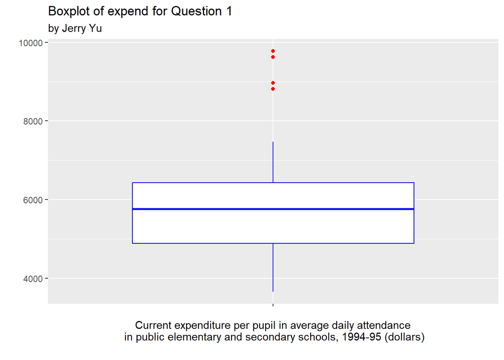

```r
#Boxplots

create_boxplot <- function(data, v, xlab, q) {
  ggplot(data = data, aes(x = "", y = !!sym(v))) +
    geom_boxplot(color = "blue", outlier.color = "red") +
    labs(title = paste("Boxplot of", v, "for Question", q),
         subtitle = "by Jerry Yu") +
    xlab(xlab) +
    ylab("")
}

create_boxplot(
  sat,
  "expend",
  "Current expenditure per pupil in average daily attendance\n in public elementary and secondary schools, 1994-95 (dollars)
",
"1"
)
```

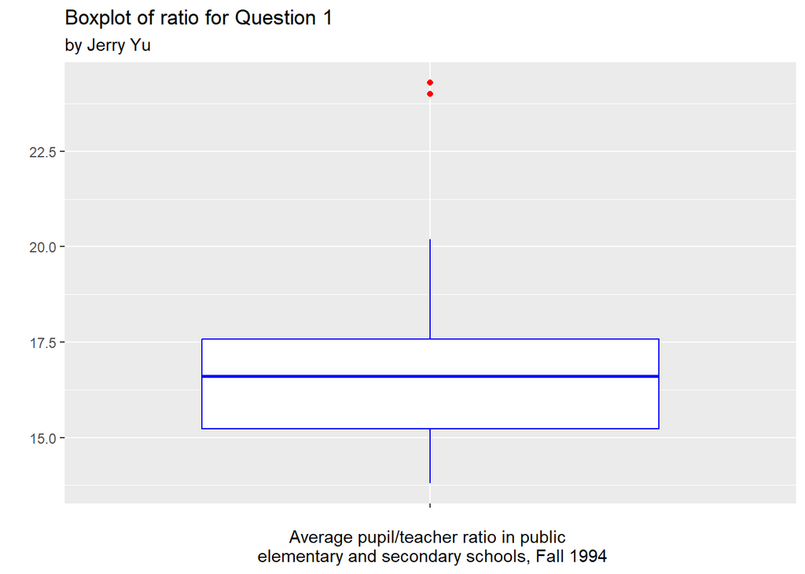

```r
create_boxplot(
  sat,
  "ratio",
  "Average pupil/teacher ratio in public \n elementary and secondary schools, Fall 1994",
  "1"
)
```

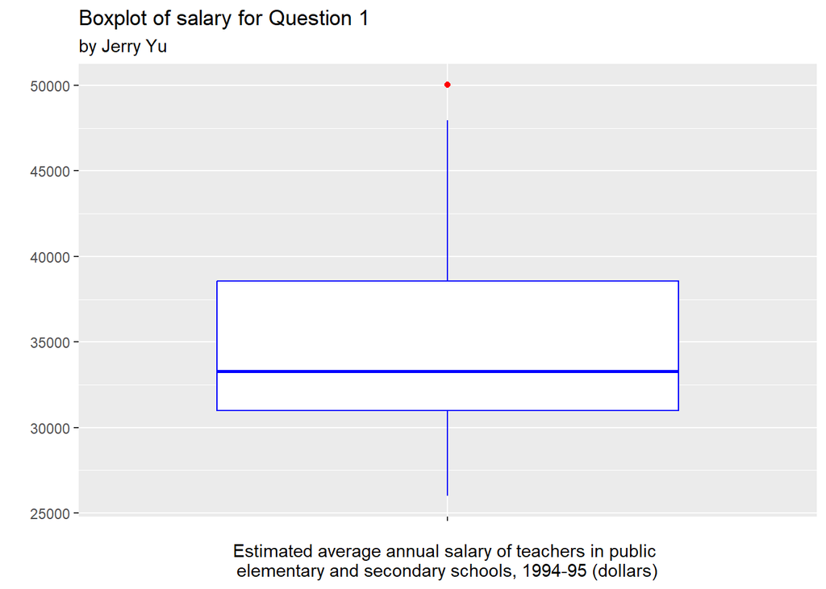

```r
create_boxplot(
  sat,
  "salary",
  "Estimated average annual salary of teachers in public \n elementary and secondary schools, 1994-95 (dollars) ",
  "1"
)
```

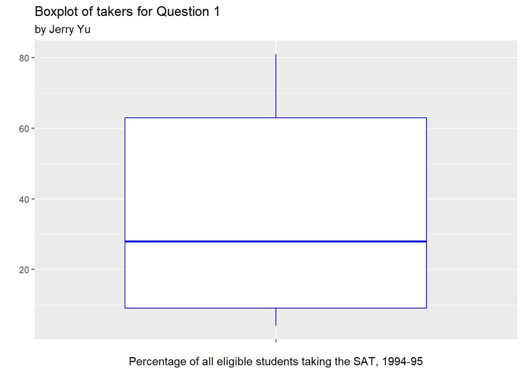

```r
create_boxplot(sat,
               "takers",
               "Percentage of all eligible students taking the SAT, 1994-95",
               "1")
```

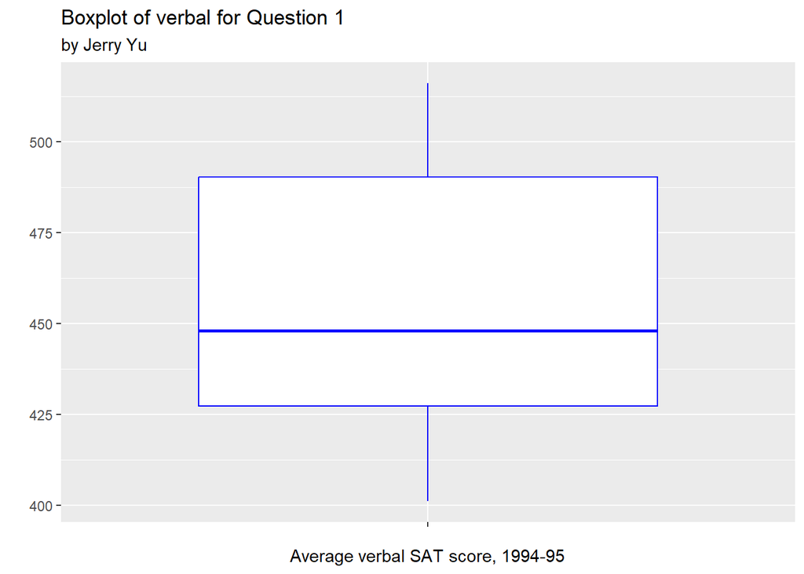

```r
create_boxplot(sat, "verbal", "Average verbal SAT score, 1994-95", "1")
```

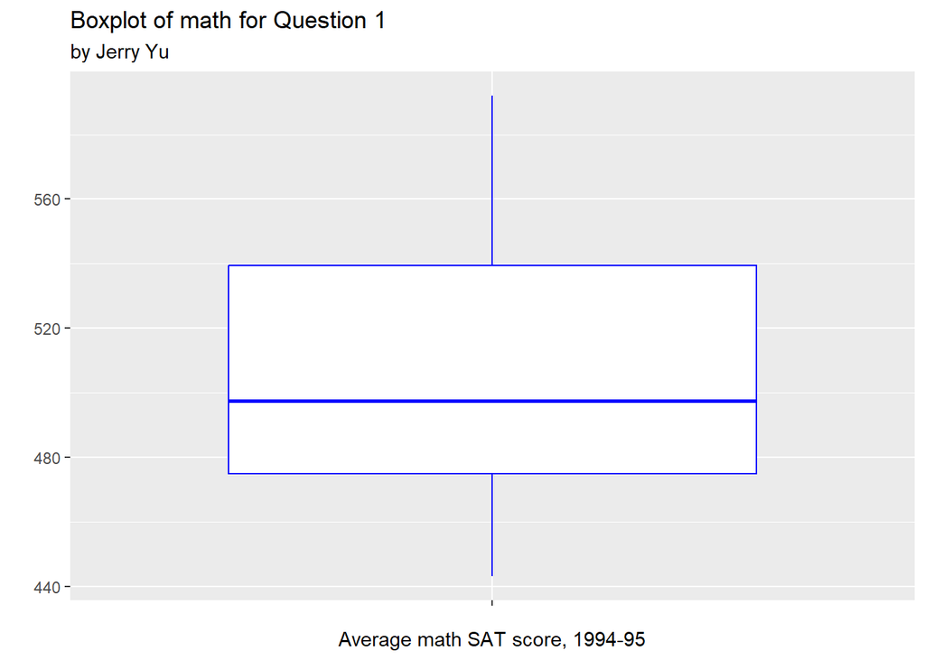

```r
create_boxplot(sat, "math", "Average math SAT score, 1994-95", "1")
```

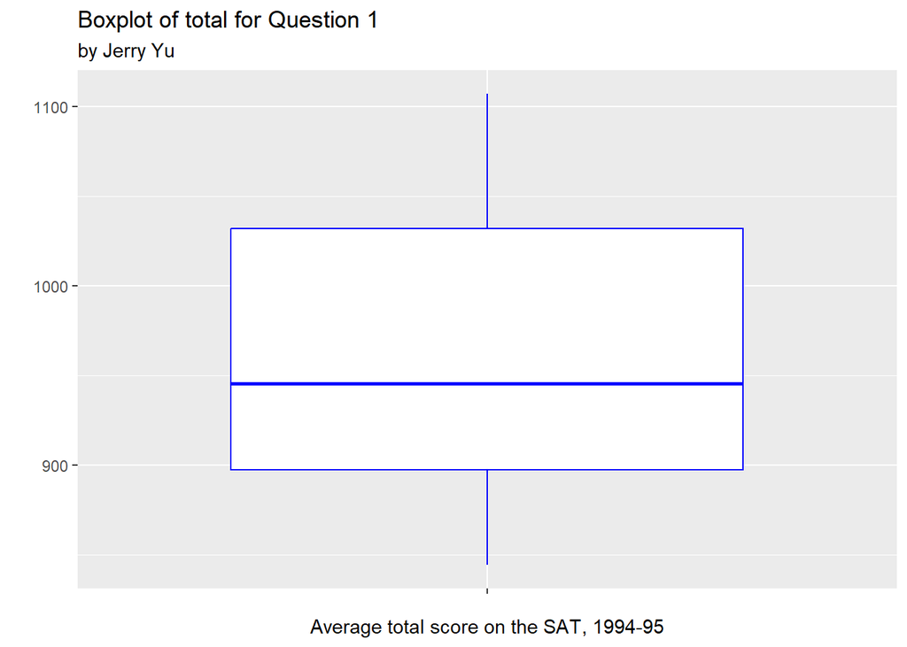

```r
create_boxplot(sat, "total", "Average total score on the SAT, 1994-95", "1")
```

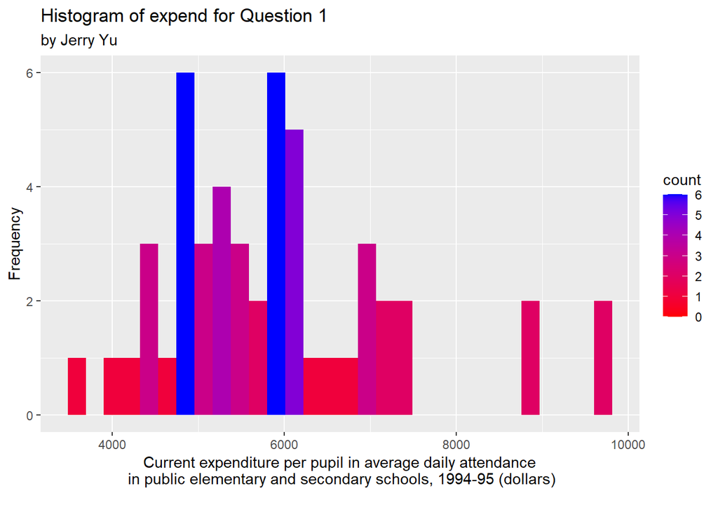

```r
# Create Histogram

create_histogram <- function(d, v, xlab, q) {
  ggplot(data = d, aes(x = !!sym(v), fill = ..count..)) +
    geom_histogram() +
    scale_fill_gradient(low = "red", high = "blue") +
    labs(title = paste("Histogram of", v, "for Question", q),
         subtitle = "by Jerry Yu") +
    xlab(xlab) +
    ylab("Frequency")
}

create_histogram(
  sat,
  "expend",
  "Current expenditure per pupil in average daily attendance\n in public elementary and secondary schools, 1994-95 (dollars)
",
"1"
)
```

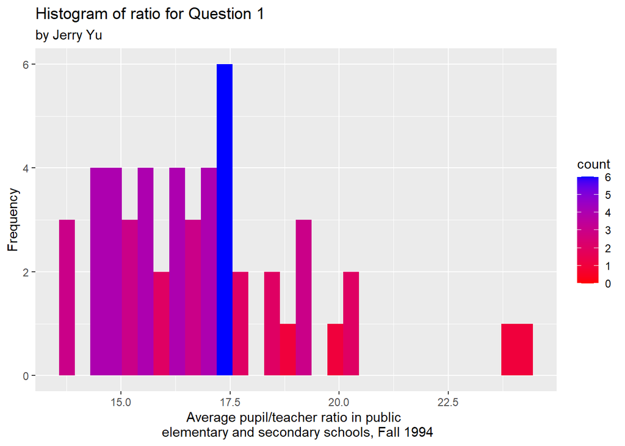

```r
create_histogram(
  sat,
  "ratio",
  "Average pupil/teacher ratio in public \n elementary and secondary schools, Fall 1994",
  "1"
)
```

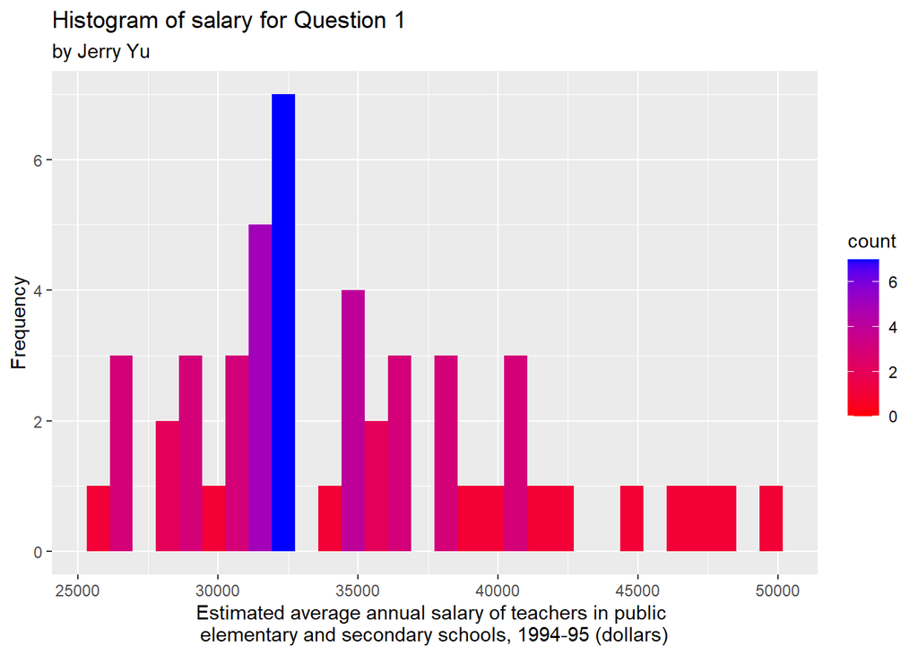

```r
create_histogram(
  sat,
  "salary",
  "Estimated average annual salary of teachers in public \n elementary and secondary schools, 1994-95 (dollars) ",
  "1"
)
```